# Réaliser des graphiques avec `ggplot2`

## Ajout de plusieurs couches

Nous allons maintenant ajouter d’autres `geom_objects` au même graphique. Par exemple, des points pour les valeurs des individus en plus du boxplot:

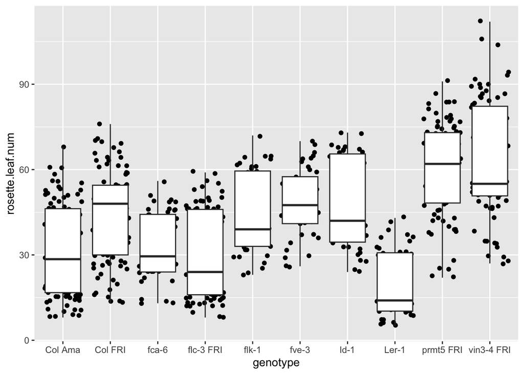

```r
ggplot(expt1, aes(genotype, rosette.leaf.num)) +
  geom_jitter() +
  geom_boxplot()
```

> **Exercice 2:** Modifiez le graphique pour que les points soient devant plutôt que derrière les boxplots.

> **BONUS**: Ajouter la géométrie dotplot plutôt que jitter. Utilisez les exemples dans l’aide (avec ?nom de fonction) pour savoir comment l’utiliser, ou lisez [cette page de blog](http://www.sthda.com/english/wiki/ggplot2-dot-plot-quick-start-guide-r-software-and-data-visualization)

## Couleurs!

Changeons la couleur des boxplots:

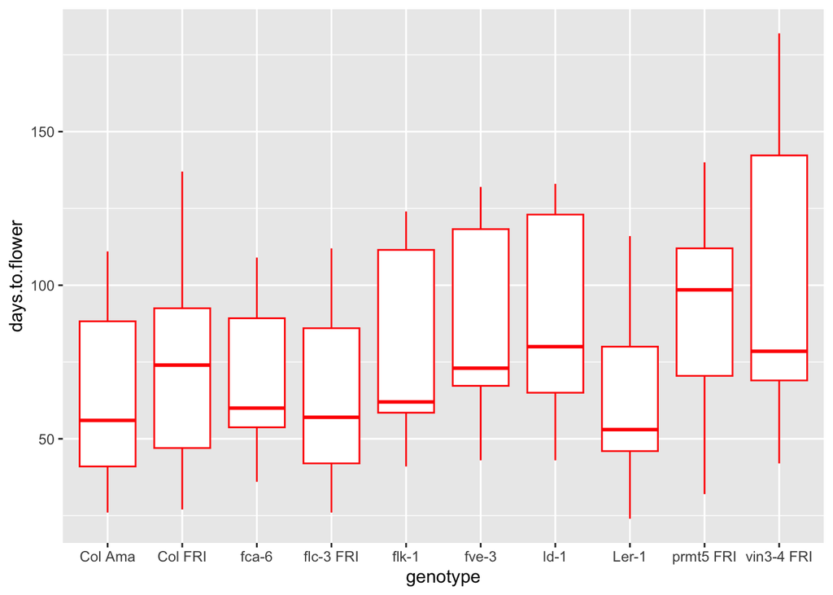

```r
ggplot(expt1, aes(genotype, days.to.flower)) +
  geom_boxplot(colour = "red")
```

Ou la couleur à l’intérieur ( *fill*) des boxplots:

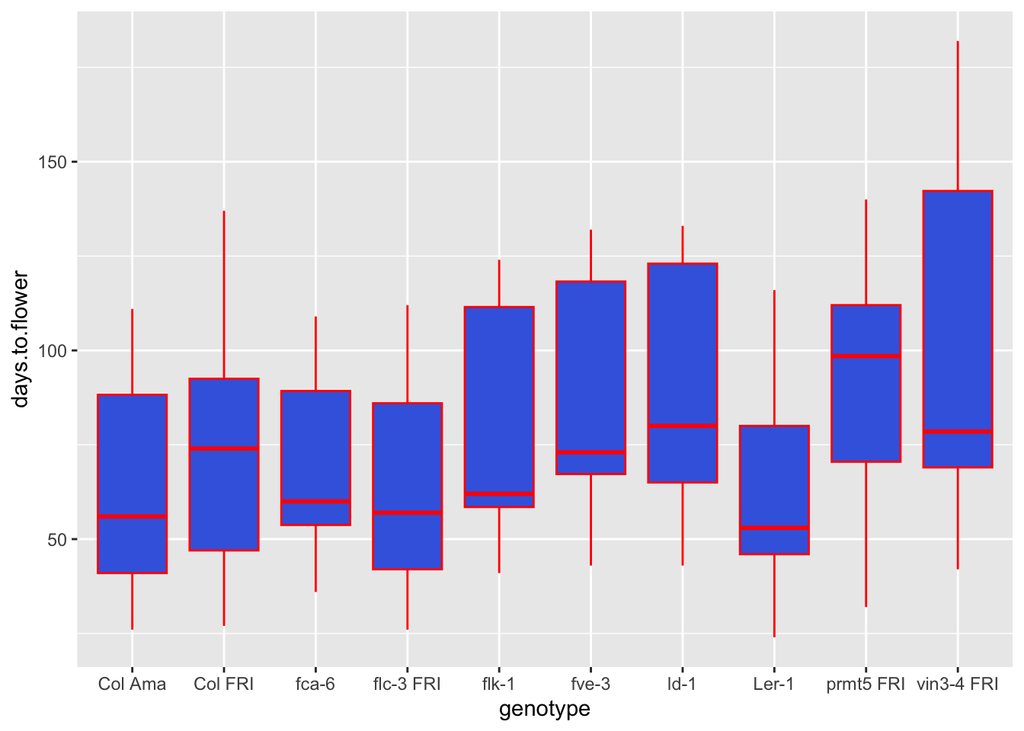

```r
ggplot(expt1, aes(genotype, days.to.flower)) +
  geom_boxplot(colour = "red", fill = "royalblue")
```

Ou même leur transparence:

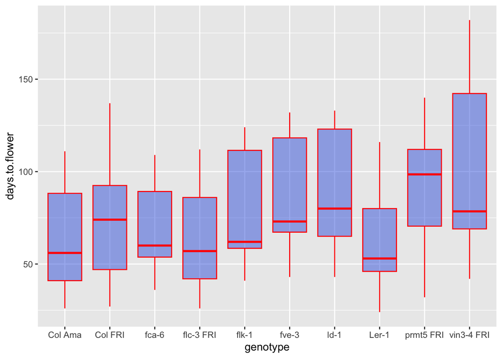

```r
ggplot(expt1, aes(genotype, days.to.flower)) +
  geom_boxplot(colour = "red", fill = "royalblue", alpha = 0.5)
```

C’est sympa, mais cela ne nous apporte pas d’information en plus sur les données.

Par exemple, ajoutons une couleur qui change en fonction d’un des traitements auquel les plantes ont été exposées (par exemple `fluctuation`). En langage `ggplot2`, nous voulons lier la valeur de la variable `fluctuation` à la couleur dans l’ *aesthetic* du graphique.

Nous devons donc inclure cette information dans `aes()`:

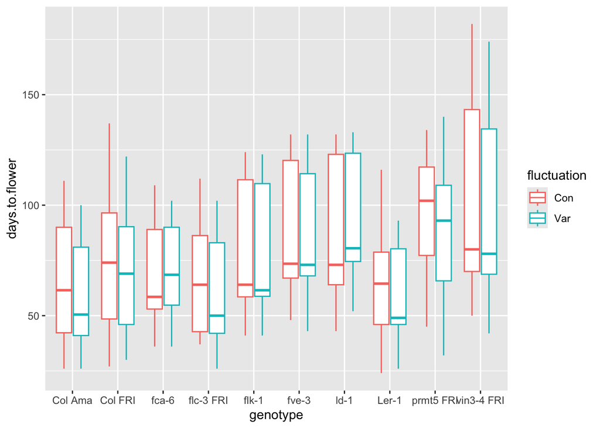

```r
ggplot(expt1, aes(genotype, days.to.flower, colour = fluctuation)) +
  geom_boxplot()
```

Wow! ggplot a automatiquement séparé les données de chaque génotype en deux groupes en fonction de `fluctuation` et leur a attribué une couleur.

Imaginons que nous voulons ajouter les points pour les valeurs des individus, sans couleur, derrière les boxplots colorés:

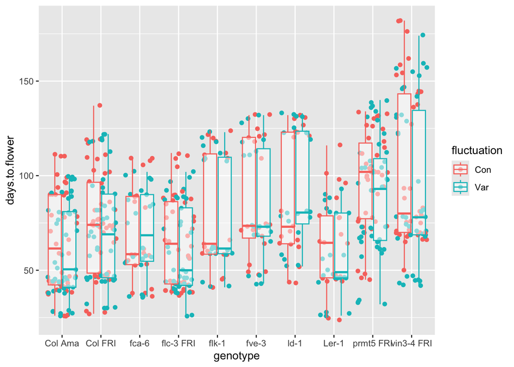

```r
ggplot(expt1, aes(genotype, days.to.flower, colour = fluctuation)) +
  geom_jitter() +
  geom_boxplot(alpha = 0.5)
```

Ce n’est pas ce que nous voulons. L’aesthetique `colour` a été liée à *toutes* les géométries du graphique. C’est parce qu’elle a été définie dans la fonction `ggplot()`, qui affecte tous les `geom_object` qui viennent après.

Mais nous pouvons aussi définir l’aesthetique dans chaque géométrie:

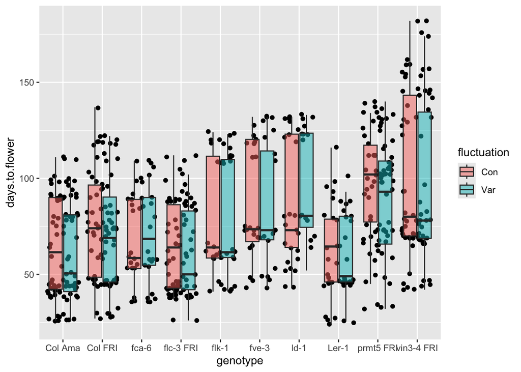

```r
ggplot(expt1, aes(genotype, days.to.flower)) +
  geom_jitter() +
  geom_boxplot(aes(fill = fluctuation), alpha = 0.5)
```

> **Exercice 3:** Nous voulons étudier la relation entre le nombre de feuille de rosette et la longueur la limbe des feuilles (en mm) pour les génotypes.

> Pour cela, dessinez un scatter plot (`geom_point()`) entre `blade.length.mm` et `rosette.leaf.num` en colorant les points en fonction de `genotype`.

> Que se passe t-il si les points sont colorés en fonction de `days.to.bolt`?

> **BONUS**: Dessinez un scatter plot (`geom_point()`) entre `blade.length.mm` et `rosette.leaf.num` en colorant les points en fonction de `vernalization`, et changez la couleur des points pour que “NV” soit en bleu et “V” soit en vert. *Aide*: Trouvez la solution en ligne (par exemple en tapant “change color points ggplot R”)

## Facetting

Souvent trop de variables, ou de groupes, sont dans nos données pour pouvoir uniquement utiliser les couleurs pour les discriminer.

C’est le cas par exemple du scatterplot produit dans l’exercice précédent, où les points sont colorés en fonction du génotype. Il est difficile de bien discerner les données pour chaque génotype car ils sont très rapprochés. L’idéal serait d’avoir un scatterplot par génotype.

Ceci est assez facile à faire avec`ggplot2`, il suffit d’ajouter une couche au graphique appelée “facet”:

- `facet_grid()` - qui permet d’organiser les panneaux du graphique en lignes et/ou colonnes
- `facet_wrap()` - qui permet d’organiser les panneaux du graphique à la suite les uns des autres qui reviennent à la ligne après un certain nombre de panneaux.

Voyons comment `facet_grid()` fonctionne:

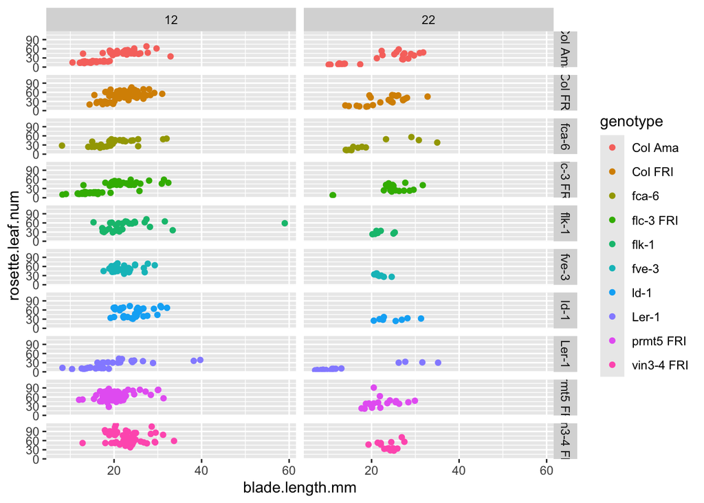

```r
ggplot(expt1, aes(blade.length.mm, rosette.leaf.num, colour = genotype)) +
    geom_point() +
    facet_grid(genotype ~ temperature)
```

Dans `facet_grid()`, nous utilisons la notation `(ligne ~ colonne)` pour définir les variables qui sont utilisées pour séparer les panneaux en ligne et colonnes.

> **Exercice 4:** Les couleurs n’apportent plus d’information supplémentaire. Pensez à une utilisation plus intéressante des couleurs dans ce graphique.

Il est possible de ne préciser qu’une variable dans `facet_grid()` :

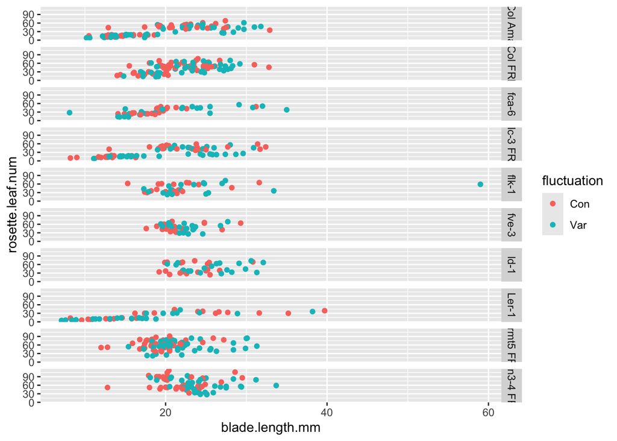

```r
# Faceter en ligne
ggplot(expt1, aes(blade.length.mm, rosette.leaf.num, colour = fluctuation)) +
    geom_point() +
    facet_grid(genotype ~ .)
```

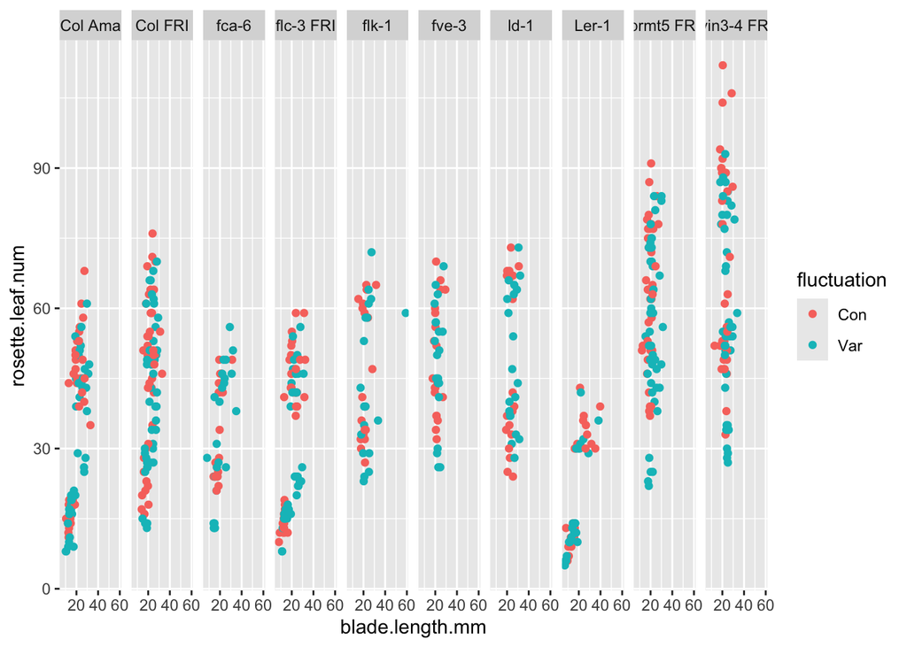

```r
# Faceter en colonne
ggplot(expt1, aes(blade.length.mm, rosette.leaf.num, colour = fluctuation)) +
    geom_point() +
    facet_grid(. ~ genotype)
```

Il est aussi possible d’utiliser `facet_wrap()` si l’on n’utilise qu’une variable pour séparer les données :

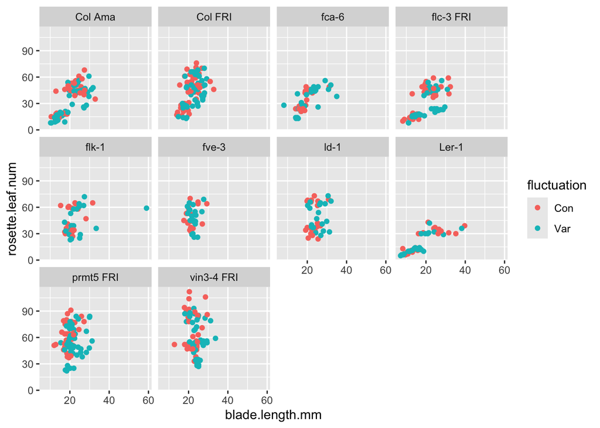

```r
ggplot(expt1, aes(blade.length.mm, rosette.leaf.num, colour = fluctuation)) +
    geom_point() +
    facet_wrap( ~ genotype)
```

> **Exercice 5:** Modifiez le graphique précédent afin de séparer les données (facet) en fonction de `fluctuation` en ligne, et `day.length` en colonne et de colorer les points en fonction du génotype.

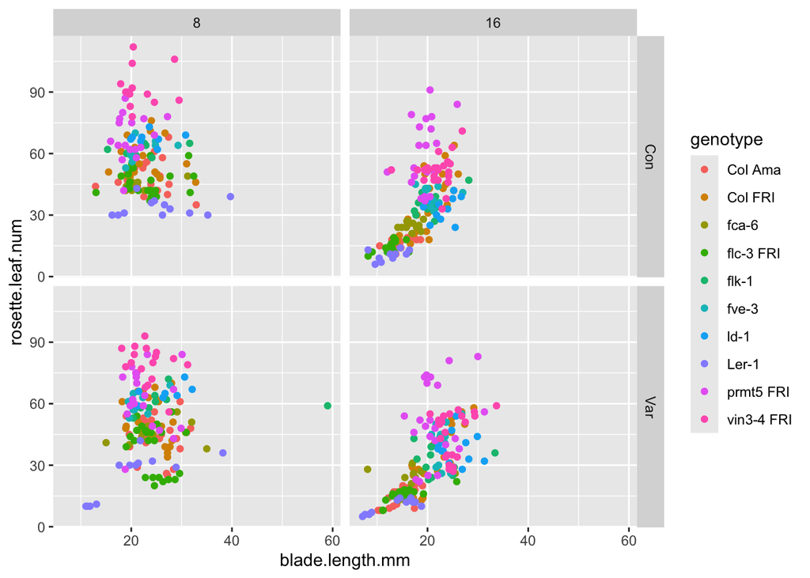

En conclusion, **il est possible de représenter de nombreuses informations en combinant efficacement facets, couleurs et autres aesthetiques!**

> **Exercice 6**: Reproduisez le graphique suivant (ou quelque chose d’approchant):

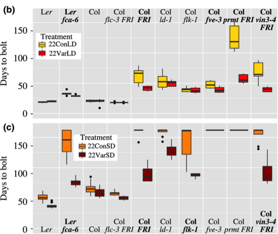

> .

> **Indice**: facet le graphique avec `day.length` et `temperature` et colorer l’intérieur des boxplot en fonction de `fluctuation`.

# Pour aller plus loin

## Changer l’apparence d’un graphique en utilisant les thèmes

Tous les éléments d’un ggplot sont modifiables. Les **thèmes** permettent de modifier l’apparence du graphique. Voici quelques exemples.

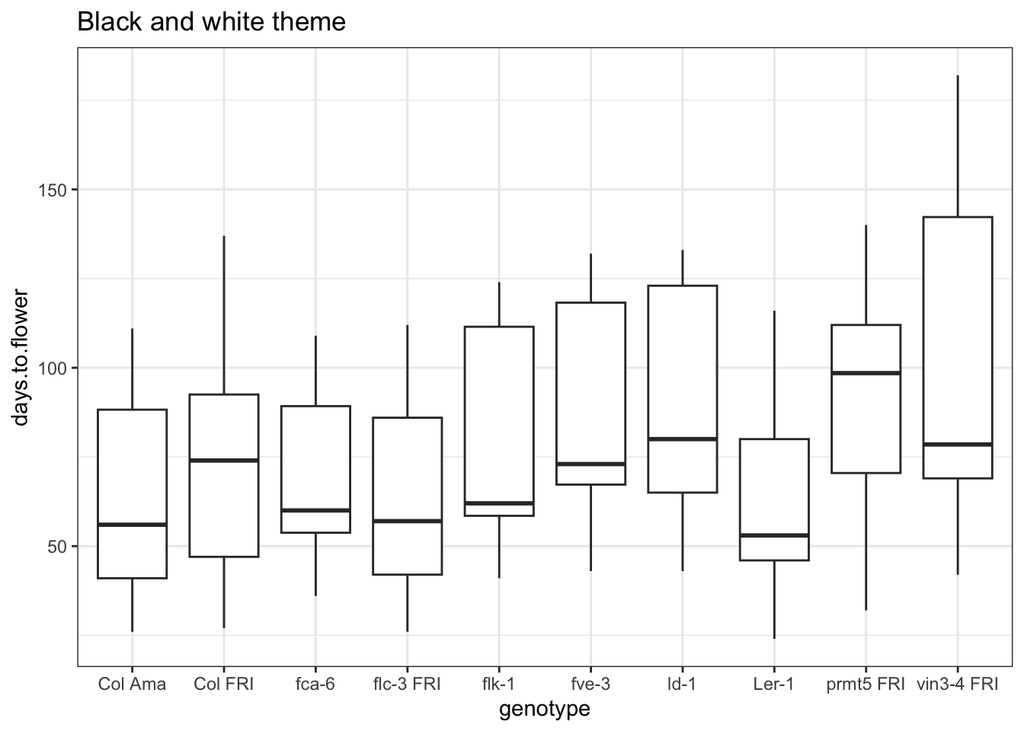

```r
# Example de thèmes existants dans ggplot2
ggplot(expt1, aes(genotype, days.to.flower)) +
  geom_boxplot() +
  theme_bw() +
  labs(title = "Black and white theme")
```

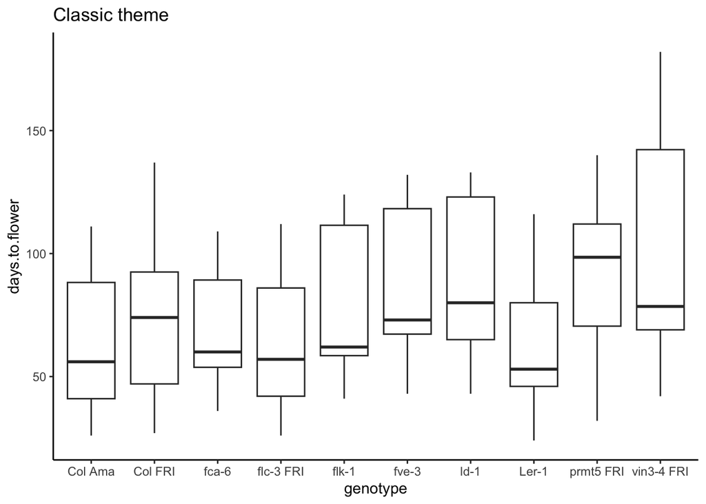

```r
ggplot(expt1, aes(genotype, days.to.flower)) +
  geom_boxplot() +
  theme_classic() +
  labs(title = "Classic theme")
```

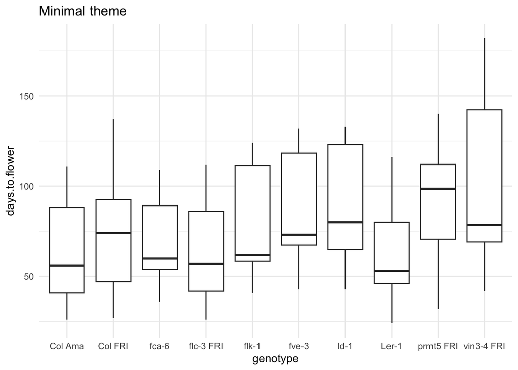

```r
ggplot(expt1, aes(genotype, days.to.flower)) +
  geom_boxplot() +
  theme_minimal() +
  labs(title = "Minimal theme")
```

La fonction `theme()` peut être utilisée pour modifier des éléments en particulier du graphique. Il y a tellement de possibilités que le mieux est de rechercher sur internet la modification que vous voulez faire.

Par exemple, en recherchant “vertical labels x axis ggplot2” nous obtenons [cette solution](https://stackoverflow.com/questions/1330989/rotating-and-spacing-axis-labels-in-ggplot2):

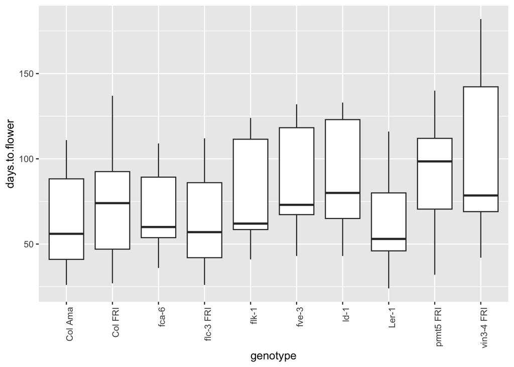

```r
ggplot(expt1, aes(genotype, days.to.flower)) +
  geom_boxplot() +
  theme(axis.text.x = element_text(angle = 90, hjust = 1))
```

Rechercher “altering plot colours ggplot2” donne [ceci](http://www.sthda.com/english/wiki/ggplot2-colors-how-to-change-colors-automatically-and-manually), qui apporte cette solution:

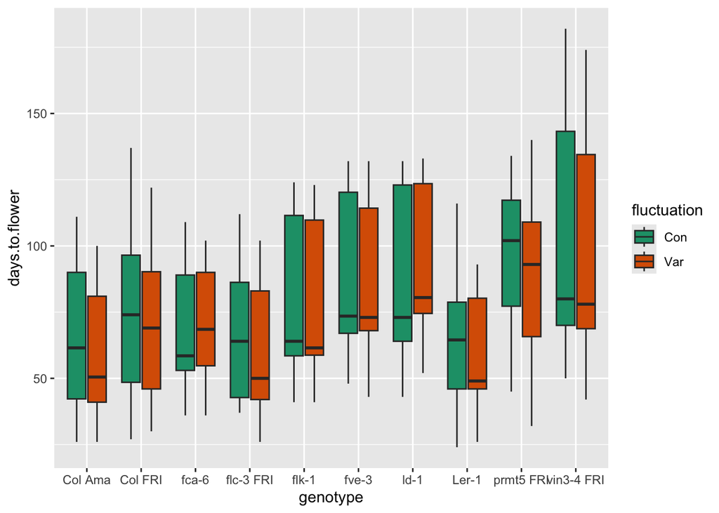

```r
ggplot(expt1, aes(genotype, days.to.flower, fill = fluctuation)) +
  geom_boxplot() +
  scale_fill_brewer(palette="Dark2")
```

## Combiner plusieurs graphiques dans une même figure

Parfois nous voulons crée une figure contenant plusieurs graphiques, c’est le cas dans la plupart des articles scientifiques.

Par exemple le graphique que vous avez reproduit hier correspond aux panels B et C d’une figure de [Burghard et al 2015](https://nph.onlinelibrary.wiley.com/doi/full/10.1111/nph.13799)

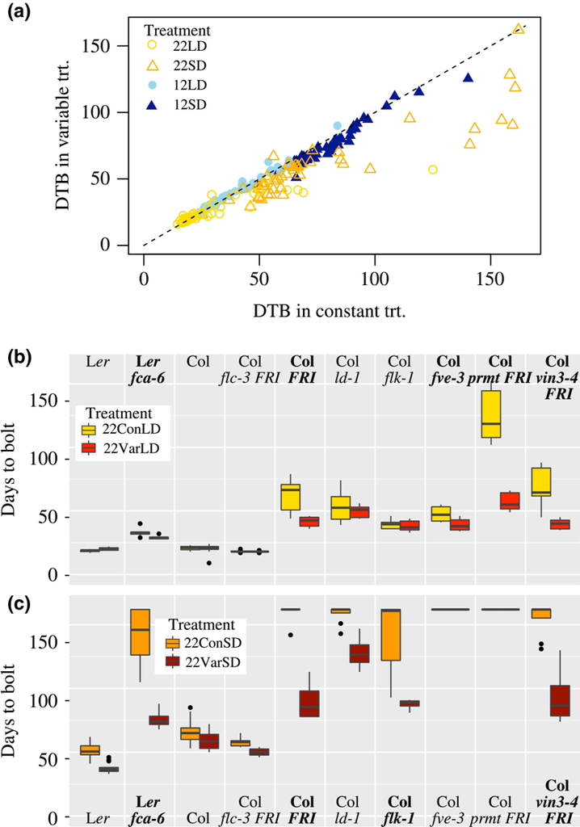

Nous allons faire quelque chose de similaire avec un scatterplot en panel A, et des boxplots en panel B.

Pour cela nous allons utiliser la fonction `ggarrange()` qui est dans le package `ggpubr`.

Tout d’abord, nous devons charger cette librairie dans R:

```r
library(ggpubr)
```

Ensuite, faisons chaque graphique indépendamment et sauvons les dans un objet:

- Un scatterplot montrant la relation entre le nombre de feuilles et le nombre de jours jusqu’à floraison, coloré en fonction du traitement:

```r
panelA <- ggplot(expt1, aes(rosette.leaf.num, days.to.bolt, colour = fluctuation)) +
    geom_point()
```

- Des boxplots du nombre de jours jusqu’à floraison pour les différent génotypes, séparés en fonction de la température, et colorés en fonction du traitement (fluctuation ou non):

```r
panelB <- ggplot(expt1, aes(genotype, days.to.bolt, fill = fluctuation)) +
    geom_boxplot() +
    facet_grid(. ~ temperature) +
  theme(axis.text.x = element_text(angle = 90, hjust = 1))
```

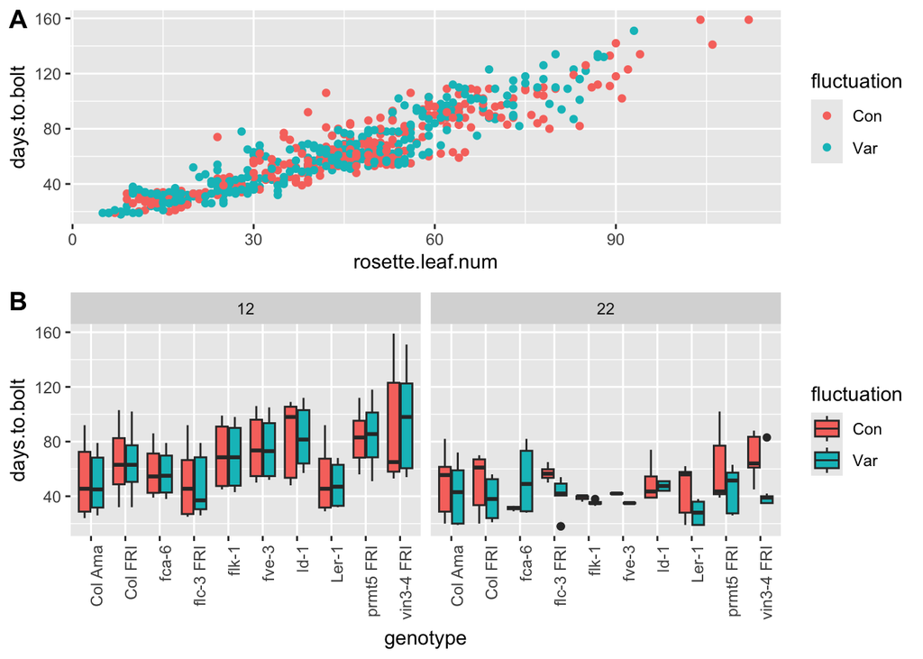

```r
ggarrange(panelA, panelB, nrow=2, labels =c("A", "B"),heights = c(1.5, 2))
```

## Créer des graphiques avec des animations

Si nous postons les graphiques en ligne, cela peut apporter un plus d’inclure une animation dans le graphique, à condition que cela apporte des informations supplémentaires. C’est possible avec le package `gganimate`!

Tout d’abord, chargeons le package `gganimate`:

```r
library(gganimate)
library(gapminder)
```

Pour créer une animation, il faut utiliser la fonction `transition_states()` à notre graphique (avec un *+*)

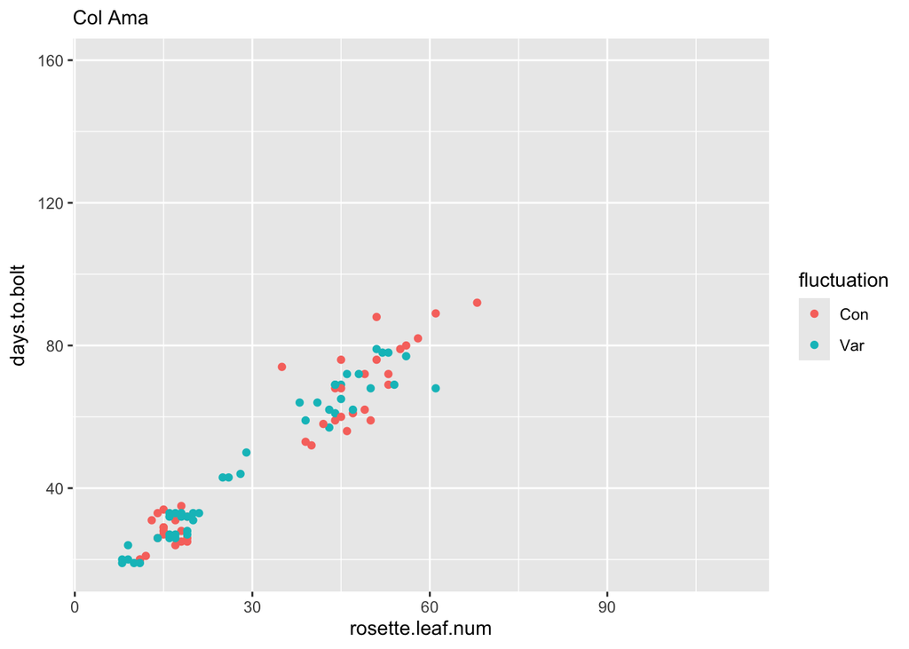

```r
ggplot(expt1, aes(rosette.leaf.num, days.to.bolt, colour = fluctuation)) +
    geom_point()  +
  transition_states(states = genotype, wrap = FALSE, transition_length = 1, state_length = 3) +
  ease_aes('linear') +
  labs(subtitle = "{closest_state}")
```

L’animation peut ensuite être sauvée en utilisant la fonction anim_save()

## Interactivité

Pour aller plus loin, il est même possible de créer des graphiques interactifs en utilisant le package `plotly`.

```r
library(plotly)
```

Il faut d’abord mettre le graphique dans un objet, puis utiliser cet objet dans la fonction `ggplotly()`.

```r
# Mettre le graphique dans l'objet p1
p1 <- ggplot(expt1, aes(rosette.leaf.num, days.to.bolt, colour = fluctuation)) +
  geom_point() +
  facet_wrap(~genotype)

# Utiliser la fonction ggplotly pour faire un graphique intéractif
ggplotly(p1)
```

[interactive chart not shown]

Plutôt que d’avoir un graphique par génotype, il est possible d’ajouter un curseur pour montrer les données des génotypes de manière interaction en utilisant l’argument ‘frame’:

```r
# Mettre le graphique dans l'objet p1
p2 <- ggplot(expt1, aes(rosette.leaf.num, days.to.bolt, colour = fluctuation, frame=genotype)) +
  geom_point()

# Utiliser la fonction ggplotly pour faire un graphique intéractif
ggplotly(p2)
```

[interactive chart not shown]

# Extras

D’autres packages qui peuvent apporter un plus à `ggplot2`:

- [`ggridges`](https://cran.r-project.org/web/packages/ggridges/vignettes/introduction.html) pour faire des graphiques “ridge”
- [`GGally`](https://ggobi.github.io/ggally/) pour représenter automatiquement les relations entre des données

# Ressources et liens utiles

- [Gallerie de graphiques pouvant être réalisés avec ggplot2](https://www.r-graph-gallery.com/)
- [Arbre de décision des graphiques](https://www.data-to-viz.com/)
- [Antisèche pour ggplot2](https://raw.githubusercontent.com/rstudio/cheatsheets/main/data-visualization.pdf)

# Contrôle continu à faire pour la prochaine séance

[Retour à la page d’accueil](https://scortijo.github.io/2026_L3_R/)